# Comparing prioritization methods

June 21, 2016

## 1. Setup and background

Many different heuristic and optimization have been developed over the year to solve minimum-set, maximum-coverage, and maximum utility type of problems. While comparing different methods is usually like comparing apples to oranges, especially from practical conservation planning point of view such comparisons can have use. Here, I compare three methods that fall into maximum-coverage category.

### 1.1 Zonation tutorial data

For testing purposes, we’re going to use the [Zonation tutorial data](https://github.com/cbig/zonation-tutorial). The dataset is fairly small and useful for the purpose of testing.

Let’s start by reading in the data and inspecting the individual species features (N=7). The values in each raster are in range [0, 1] and indicate the propabilty of occurrence.

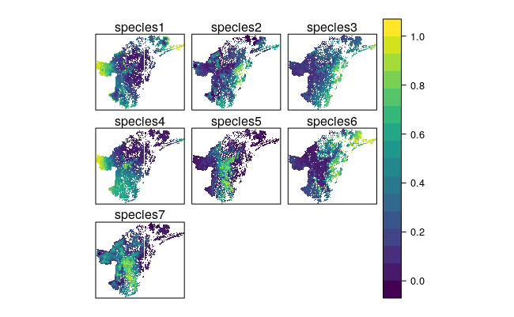

```r
# Set up directory path for the tutorial data
z_tutorial_dir <- "~/dev/git-data/zonation-tutorial"
z_tutorial_data_dir <- file.path(z_tutorial_dir, "data")
tutorial_files <- list.files(path = z_tutorial_data_dir, pattern = "species.+\\.tif$",
                             full.names = TRUE)
sp_rasters <- raster::stack(tutorial_files)
# For some mysterious reason, minmax isn't set automatically for sp_rasters[[1]]
# (species1)
sp_rasters[[1]] <- setMinMax(sp_rasters[[1]])
# Generate template for other spatial data later on
nrows <- nrow(sp_rasters)
ncols <- ncol(sp_rasters)
template <- extent(sp_rasters) %>%
              raster(nrows = nrows, ncols = ncols, vals = 1)
template[is.na(sp_rasters[[1]])] <- NA
levelplot(sp_rasters, margin = FALSE, scales = list(draw = FALSE),
          col.regions = viridis, layout = c(3, 3))
```

### 1.2 Generate cost data

While we will not be using cost data as in actually considering cost data, but we need for as a constraint data for the Gurobi ILP optimization. The cost is `1.0` in each cell, basically meaning that it translates into number of cells. This way it is possible to link an aerial target (such as the top 10% of the landscape) into a budgetary constraint.

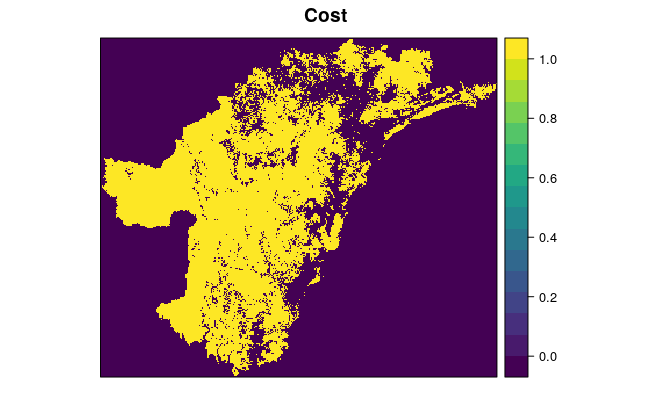

```r
cost <- extent(sp_rasters) %>%
  raster(nrows = nrows, ncols = ncols, vals = 1)
# Alternatively, cost data can be simulated
# cost <- gaussian_field(r, 20, mean = 1000, variance = 500) #%>%
#  setNames("cost")
# Fill areas normalle NA (NoData) with cost of 0
cost[is.na(sp_rasters[[1]])] <- 0
levelplot(cost, main = "Cost", margin = FALSE, scales = list(draw = FALSE),
          col.regions = viridis)
```

## 2. Prioritization methods

Here, we’re testing three different prioritization methods against each other at increasing level of complexity:

1. Rarity-wighted richness
2. Zonation (two methods: core-area Zonation and additive benefit function)
3. Integer programming (ILP) using Gurobi solver

### 2.1 Rarity-Weighted Richness (RWR)

From [Albuquerque and Beier (2015)](http://dx.plos.org/10.1371/journal.pone.0119905):

“Williams et al. (1996) proposed that the rarity value of a species can be characterized by the inverse of the number of sites or planning units in which it occurs. Thus if a species is found in only 1 site, the species would have the maximum rarity score of `1/1 = 1`, and a species that occurs in 20 sites would have a rarity score of `1/20 = 0.05`. Williams et al. also proposed that the rarity scores of all species in the site can be summed to yield a single RWR value for the site:

$$\sum_{n}^{1} (1 / c)$$

where $c_{i}$ is the number of sites occupied by species $i$, and the values are summed for the $n$ species that occur in that site."

While the formulation by Albuquerque and Beier (2015) applies to binary presence/absence data, it can be extended to data where the values in each cell is a quantitative measure, e.g. the probability of occurrence. Hence, the formula becomes:

$$\sum_{n=1}^{n} \frac{o_{ij}}{\sum_{i} o_{i}}$$

where $o_{ij}$ is the *occurence level* of feature $i$ in cell $j$ and $\sum_{i} o_{i}$ is the sum of the occurrence levels of all cells of feature $i$. Below, after ranking the values are rescaled to range [0, 1]. Values close to 0 are the lowest priority locations, values close to 1 the highest.

```r
# Define a function for occurrence level normalization
ol_normalize <- function(x) {
  min <- raster::minValue(x)
  return((x - min) / raster::cellStats(x - min, "sum"))
}
# Occurrence level normalize all species rasters
sp_rasters_normalized <- ol_normalize(sp_rasters)
# Sum up all normalized occurence levels -> rarity-weighted richness
rwr <- sum(sp_rasters_normalized, na.rm = TRUE)
# Replace 0 with NA
rwr[rwr ==  0] <- NA
# Rank all cell according the RWR
rwr_rank <- rank(raster::getValues(rwr), ties.method = "random", na.last = "keep")
# Scale ranks to range [0, 1]
rwr_rank <- rwr_rank / max(rwr_rank, na.rm = TRUE)
e <- raster::extent(sp_rasters)
# Transform ranks back to a raster
rwr_rank <- raster(e, nrows = nrow(rwr), ncols = ncol(rwr), vals = rwr_rank)
```

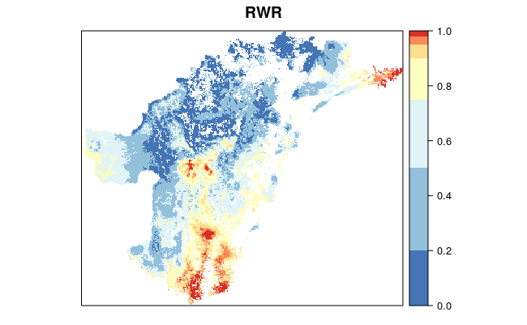

```r
levelplot(rwr_rank, margin = FALSE, main = "RWR", scales = list(draw = FALSE),
                 par.settings = rasterTheme(region = z_colors_RdYlBu$colors),
                 at = z_colors_RdYlBu$values)
```

### 2.2 Zonation (CAZ + ABF)

We’re not going to run the actual Zonation analysis, but assume that basic runs 01_core_area_zonation and 02_additive_benefit_function have been executed locally. Then, we just do load the results.

For additive benefit function, the $z$ parameter has been set to 0.25 for all species.

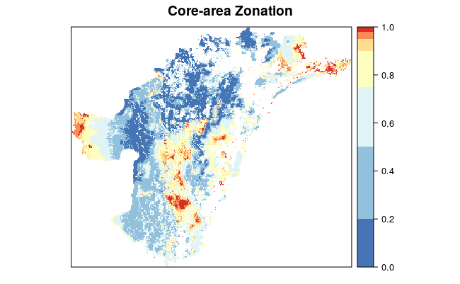

```r
caz_rank <- raster(file.path(z_tutorial_dir, "basic", "basic_output",
                             "01_core_area_zonation", "01_core_area_zonation.rank.asc"))
levelplot(caz_rank, margin = FALSE,
          par.settings = rasterTheme(region = z_colors_RdYlBu$colors),
          scales = list(draw = FALSE), at = z_colors_RdYlBu$values,
          main = "Core-area Zonation")
```

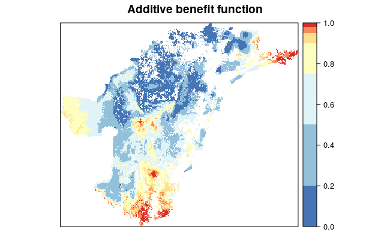

```r
result_dir <- "/home/jlehtoma/VirtualBox VMs/trusty64/zonation/zonation-tutorial"
abf_rank <- raster(file.path(result_dir, "basic", "basic_output",
                             "02_additive_benefit_function",
                             "output_02_additive_benefit_function.rank.compressed.tif"))
levelplot(abf_rank, margin = FALSE,
          par.settings = rasterTheme(region = z_colors_RdYlBu$colors),
          scales = list(draw = FALSE),
          at = z_colors_RdYlBu$values, main = "Additive benefit function")
```